# Applying Reinforcement Learning to Cartpole

by Thomas Fahrner, Mikey Maramba, and Dhruv Singal

## What is reinforcement learning?

Recent progress in deep learning has expanded beyond unsupervised and supervised learning. Reinforcement learning (RL) is a class of algorithms that establish an action-reward framework to develop an agent that chooses actions to maximize rewards [1]. This framework lends itself to Markov decision processes (MDP) [2]. The RL field has flocked to video games since they can often be analyzed as MDPs. OpenAI has created a "gym" where users can download environments (games) [3]. Users then train models on these environments in an attempt to converge on a high score.

## Cartpole

Cartpole is an inverted pendulum environment from OpenAI [4]. The goal of Cartpole is to balance the pole in an upright position. Agents have the ability to apply a left or right force on the cart. After each action/timestep, the environment returns an updated state and a reward. The game ends when the pole falls beyond 15 degrees from vertical or the cart extends beyond 2.4 units from the center. To "win" the game, the agent must receive an average reward of 195 over 100 trials.

The state has four features: [position of cart, velocity of cart, angle of pole, rotation rate of pole] = [p, v, a, r]

The reward is +1 after every timestep.

## Setting up a Cartpole/OpenAI Gym Environment

After installing OpenAI Gym via pip, you can use the core environments that gym provides. The OpenAI Gym Environment provides users with environments and functions used to extract data from the environments for training. The central function is the step function, which returns 4 values: observation, reward, done, and info. Observation stores the 'state' of the game, reward stores the amount of reward achieved by the previous action, and done determines whether to reset the environment or not (info is mostly diagnostic information).

Creating the Cartpole environment:

```python
import gym
env = gym.make('CartPole-v0')
```

```
WARN: gym.spaces.Box autodetected dtype as <class 'numpy.float32'>. Please provide explicit dtype.
```

We will use the function test_params to test the parameter sets that we generate.

```python
def test_params(env, params):
    observation = env.reset()
    total_reward = 0
    while True:
        #env.render()
        res = np.matmul(params, observation)
        if res < 0:
            action = 0
        else:
            action = 1
        observation, reward, done, info = env.step(action)
        #print(observation)
        total_reward += reward
        if done:
            break
    return total_reward
```

These are the functions we will use to display the results of our algorithms.

```python
import numpy as np
from matplotlib import pyplot as plt


env = gym.make('CartPole-v0')
env._max_episode_steps = 200  # Cap CartPole to this amount
num_samples = 10  # Number of times to utilize each algorithm


def runHillClimbing(env):
    num_episodes = []
    for i in range(num_samples):
        res = climb_hill(env)
        if res:
            num_episodes.append(res)

    plt.hist(num_episodes)
    plt.title('Hill Climbing Algorithm')
    plt.xlabel('Episodes')
    plt.ylabel('Frequency')
    plt.show()

def runGuessing(env):
    num_episodes = []
    for i in range(num_samples):
        num_episodes.append(run_guesses(env))

    plt.hist(num_episodes)
    plt.title('Random Guessing Algorithm')
    plt.xlabel('Episodes')
    plt.ylabel('Frequency')
    plt.show()

def runPolicyGradient(env):
    num_inputs = env.observation_space.shape[0]
    num_outputs = env.action_space.n
    model = build_network(num_inputs, num_outputs)
    train = build_train(model, num_outputs)

    steps_per_sample = []
    for sample in range(num_samples):
        for episode in range(5000):
            reward = run_episode(env, train, model, num_outputs)
            if reward == env._max_episode_steps:
                #print("Found reward {} after {} episodes".format(reward, episode))
                steps_per_sample.append(episode)
                break
        reset_model(model)

    plt.hist(steps_per_sample)
    plt.title('Policy Gradient Algorithm')
    plt.xlabel('Episodes')
    plt.ylabel('Frequency')
    plt.show()
```

```
WARN: gym.spaces.Box autodetected dtype as <class 'numpy.float32'>. Please provide explicit dtype.
```

## Our Approach:

We developed a variety of different algorithms to solve Cartpole. Our goals were twofold: gain exposure to the basics of RL and incorporate the deep learning techniques we learned in 490.

## Linear Models

### Random Parameters

This algorithm involves creating up to N sets of parameters randomly (for our environment, a size of 10,000 parameter sets would be more than sufficient). Each set of parameters were of length 4 and set between -1 and 1. The parameter set was then tested until the game was over. If the current set of parameters achieved a greater amount of reward than the previous maximum, the set would be saved.

```python
def run_guesses(env):
    best_params = None
    best_reward = 0
    t_found = None

    for t in range(10000):  # 10,000 random configurations, 1 each episode
        params = np.random.rand(4) * 2 - 1  # Random weights btwn -1 and 1
        reward = test_params(env, params)
        if reward > best_reward:
            best_reward = reward
            best_params = params
            t_found = t+1
            if reward == env._max_episode_steps:
                break

    return t_found
```

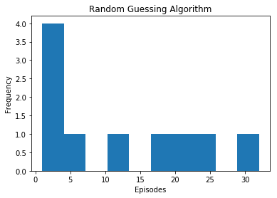

```python
runGuessing(env)
```

### Hill Climbing

This algorithm involves creating a set of parameters randomly (similar to the random parameters algorithm), testing our initial set of parameters, and then adding “noise” to the parameter set. This noise would be a random set of four numbers between -1 and 1, scaled by a factor of our choice. Similar to the other model, if the current set of parameters achieved a greater amount of reward than the previous maximum, the set would be saved. Noise would be added up to N times.

```python
def climb_hill(env, scale_noise=0.1):
    best_params = None
    best_reward = 0
    t_found = None

    # Start with random setting of the parameters
    params = np.random.rand(4) * 2 - 1

    for t in range(10000):  # Number of iterations to "climb"
        noise = (np.random.rand(4) * 2 - 1) * scale_noise
        params = params + noise  # Add noise matrix to params
        reward = test_params(env, params)
        if reward > best_reward:
            best_reward = reward
            best_params = params
            t_found = t+1
            if reward == env._max_episode_steps:
                break

    if best_reward == env._max_episode_steps:
        return t_found
    else:
        return None  # return 0 if we did not find desired reward
```

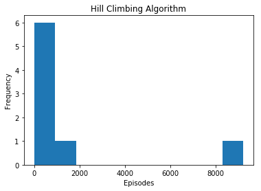

```python
runHillClimbing(env)
```

```python
from keras.models import Model
from keras import layers
from keras import backend as K
from keras import utils as np_utils
from keras import optimizers
from matplotlib import pyplot as plt


def build_network(num_inputs, num_outputs):
    # use Keras functional API to construct policy network
    network = layers.Input(shape=(num_inputs,))
    input = network

    for layer in [32, 16, 8]:
        network = layers.Dense(layer)(network)
        network = layers.Activation("relu")(network)

    network = layers.Dense(num_outputs)(network)
    network = layers.Activation("softmax")(network)

    return Model(inputs=input, outputs=network)


def build_train(model, num_outputs):
    prob_action = model.output
    encoded_action = K.placeholder(shape=(None, num_outputs), name="encoded_action")
    discount_reward = K.placeholder(shape=(None,), name="discount_reward")

    loss = K.mean(-K.log(K.sum(prob_action * encoded_action, axis=1)) * discount_reward)

    deltas = optimizers.Adam().get_updates(params=model.trainable_weights, loss=loss)

    return K.function(inputs=[model.input, encoded_action, discount_reward], outputs=[], updates=deltas)


def get_action(model, state, num_outputs):
    state = np.expand_dims(state, axis=0)
    prob_action = np.squeeze(model.predict(state))

    return np.random.choice(np.arange(num_outputs), p=prob_action)


def fit(train, states, actions, rewards, num_outputs):
    encoded_action = np_utils.to_categorical(actions, num_classes=num_outputs)
    discount_reward = get_discounted(rewards)
    train([states, encoded_action, discount_reward])


def get_discounted(rewards):
    discount_rate = 0.96
    discounted = np.zeros_like(rewards, dtype=np.float32)
    sum = 0

    for t in reversed(range(len(rewards))):
        sum = sum * discount_rate + rewards[t]
        discounted[t] = sum

    discounted -= discounted.mean() / discounted.std()

    return discounted


def run_episode(env, train, model, num_outputs):
    is_done = False
    state = env.reset()
    states = []
    actions = []
    rewards = []
    total_reward = 0

    while not is_done:
        action = get_action(model, state, num_outputs)
        new_state, reward, is_done, info = env.step(action)
        total_reward += reward

        states.append(state)
        actions.append(action)
        rewards.append(reward)

        state = new_state

    fit(train, np.asarray(states), np.asarray(actions), np.asarray(rewards), num_outputs)

    return total_reward


def reset_model(model):
    session = K.get_session()
    for layer in model.layers:
        if hasattr(layer, 'kernel_initializer'):
            layer.kernel.initializer.run(session=session)
```

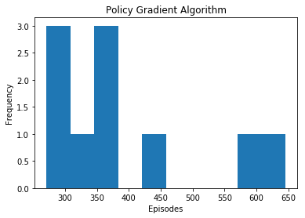

```python
runPolicyGradient(env)
```